# NYPD

2023-05-29

# NYPD Shooting Incident Data report

We will start this report by importing the data from the data.gov website. In particular, we will import the historic file that contains the NYPD Shooting incident data since 2006. The description of the file contents and terms of use can be found in the following website : https://catalog.data.gov/dataset/nypd-shooting-incident-data-historic.

## Importing the file

The following embedded code will retrieve the file from the website and will read its contents into the NYPD memory variable.

```r
url_file <- "https://data.cityofnewyork.us/api/views/833y-fsy8/rows.csv?accessType=DOWNLOAD"
NYPD <- read.csv(url_file)
```

## Tidying and transforming

In order to manipulate the data, will will first load the necessary Tidyverse libraries with the following code:

```r
library (tidyverse)
library(lubridate)
options(dplyr.summarise.inform = FALSE)
```

Then we are going to convert the date and time files of shooting events (that are in character format) to the right date/time format. Also, we will remove the fields X_COORD_CD, Y_COORD_CD (that locate the incident in NY map coordinate) as well as the Lon_Lat field as all are redundant information since th GPS coordinates are already in the file. The summary of the resulting file is displayed.

```r
NYPD_clean <- NYPD %>%
     mutate(OCCUR_DATE = mdy(OCCUR_DATE),
            OCCUR_TIME = hms(OCCUR_TIME)) %>%
     select (-c(X_COORD_CD,Y_COORD_CD,Lon_Lat))
summary(NYPD_clean)
```

```
##   INCIDENT_KEY         OCCUR_DATE           OCCUR_TIME
##  Min.   :  9953245   Min.   :2006-01-01   Min.   :0S
##  1st Qu.: 63860880   1st Qu.:2009-07-18   1st Qu.:3H 27M 0S
##  Median : 90372218   Median :2013-04-29   Median :15H 11M 0S
##  Mean   :120860536   Mean   :2014-01-06   Mean   :12H 41M 31.7091388399567S
##  3rd Qu.:188810230   3rd Qu.:2018-10-15   3rd Qu.:20H 45M 0S
##  Max.   :261190187   Max.   :2022-12-31   Max.   :23H 59M 0S
##
##      BORO           LOC_OF_OCCUR_DESC     PRECINCT      JURISDICTION_CODE
##  Length:27312       Length:27312       Min.   :  1.00   Min.   :0.0000
##  Class :character   Class :character   1st Qu.: 44.00   1st Qu.:0.0000
##  Mode  :character   Mode  :character   Median : 68.00   Median :0.0000
##                                        Mean   : 65.64   Mean   :0.3269
##                                        3rd Qu.: 81.00   3rd Qu.:0.0000
##                                        Max.   :123.00   Max.   :2.0000
##                                                         NA's   :2
##  LOC_CLASSFCTN_DESC LOCATION_DESC      STATISTICAL_MURDER_FLAG
##  Length:27312       Length:27312       Length:27312
##  Class :character   Class :character   Class :character
##  Mode  :character   Mode  :character   Mode  :character
##
##
##
##
##  PERP_AGE_GROUP       PERP_SEX          PERP_RACE         VIC_AGE_GROUP
##  Length:27312       Length:27312       Length:27312       Length:27312
##  Class :character   Class :character   Class :character   Class :character
##  Mode  :character   Mode  :character   Mode  :character   Mode  :character
##
##
##
##
##    VIC_SEX            VIC_RACE            Latitude       Longitude
##  Length:27312       Length:27312       Min.   :40.51   Min.   :-74.25
##  Class :character   Class :character   1st Qu.:40.67   1st Qu.:-73.94
##  Mode  :character   Mode  :character   Median :40.70   Median :-73.92
##                                        Mean   :40.74   Mean   :-73.91
##                                        3rd Qu.:40.82   3rd Qu.:-73.88
##                                        Max.   :40.91   Max.   :-73.70
##                                        NA's   :10      NA's   :10
```

## Visualizing Data

Having normalized and cleaned the data, we are now going to visualize the information using certain criteria. This will help in creating some insights in the shooting events both from a location and time distribution perspectives.

First we will create a time sequence of evolution of the number of incidents. In order to do that we will transform the dates in month/year and group by that field counting the number of incidents that happen in that particular month. The evolution of the shooting incidents from the year 2006 to the end of 2022 presents this interesting aspect:

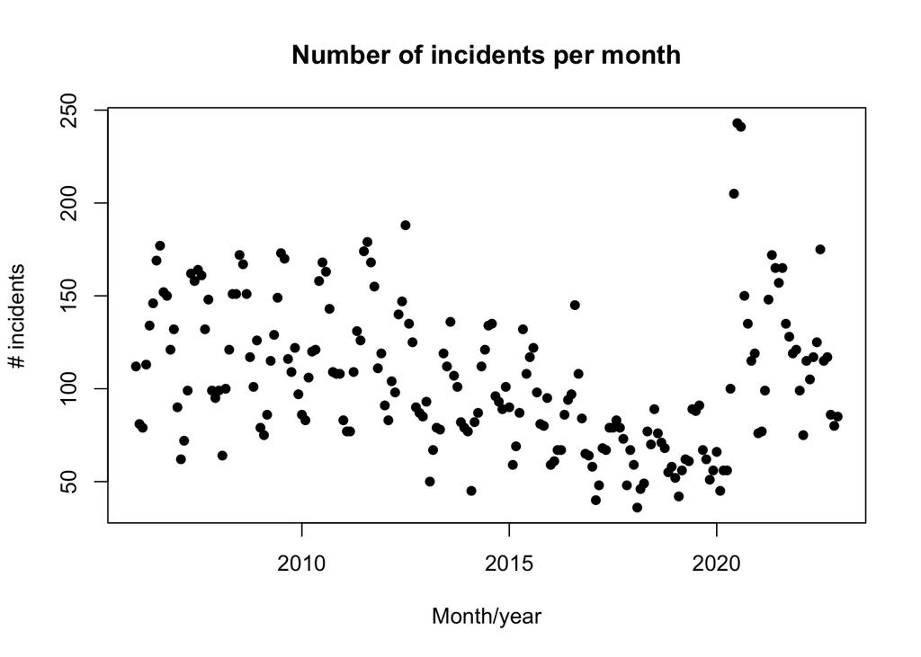

```r
NYPD_by_month <- NYPD_clean %>%
     mutate(OCCUR_MONTH = format(as.Date(OCCUR_DATE), "%Y-%m")) %>%
     select(INCIDENT_KEY,OCCUR_MONTH) %>%
     ungroup()
NYPD_by_month_count <- NYPD_by_month %>%
     group_by (OCCUR_MONTH) %>%
     summarise (Incidents = n_distinct(INCIDENT_KEY))
NYPD_by_month_count <- NYPD_by_month_count %>%
     mutate(OCCUR_MONTH = ym(OCCUR_MONTH))
x <- NYPD_by_month_count$OCCUR_MONTH
y <- NYPD_by_month_count$Incidents
plot(x,y,xlab="Month/year",ylab="# incidents", pch=16)
title("Number of incidents per month")
```

In order to have a sense of the geographical distribution of the events, we will now transform the data and visualize the cumulative number of shooting incidents by neighborhood divided by population of the neighborhood. With that, we will obtain a bar graph like this:

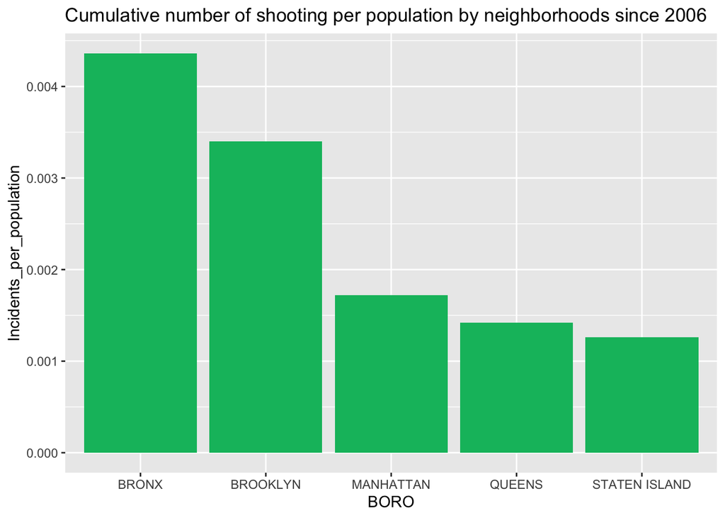

```r
NYPD_by_BORO <- NYPD_clean %>%
     group_by(BORO) %>%
     summarise(Incidents = n_distinct(INCIDENT_KEY)) %>%
     mutate (Population = c(1379946,2590516,1596273,2278029,491133 )) %>%
     mutate (Incidents_per_population = Incidents/Population) %>%
     select(Incidents_per_population, BORO) %>%
     ungroup()
ggplot(NYPD_by_BORO, aes(x = BORO, y = Incidents_per_population)) + geom_bar(stat = "identity", fill = "#00bc6c") + ggtitle("Cumulative number of shooting per population by neighborhoods since 2006")
```

## Analyzing Data

We are now going to have a look at the shooting incidents and split those that involve a murder and those that do not. In order to accomplish that analysis, we will transform the data again and group by the type of shooting incident. Drawing two series : one for murder events, the other for non-murder events

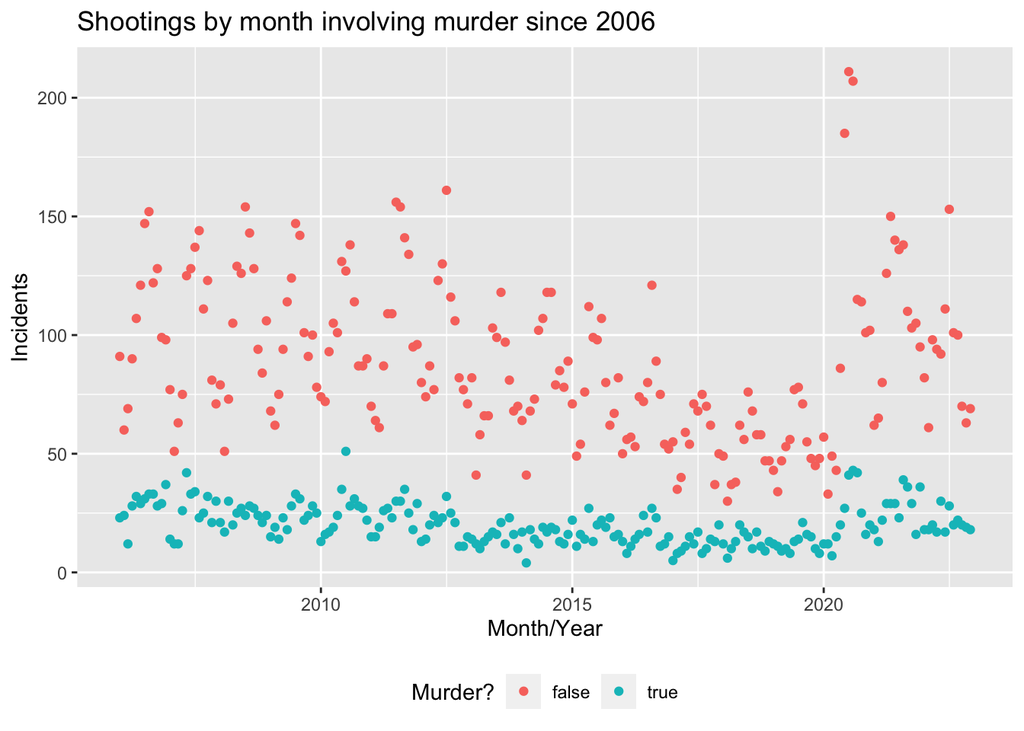

```r
NYPD_type <- NYPD_clean %>%
          mutate(OCCUR_MONTH = format(as.Date(OCCUR_DATE), "%Y-%m")) %>%
          mutate(OCCUR_MONTH = ym(OCCUR_MONTH)) %>%
          group_by(OCCUR_MONTH, STATISTICAL_MURDER_FLAG) %>%
          summarise(Incident = n_distinct(INCIDENT_KEY)) %>%
          select(Incident, OCCUR_MONTH, STATISTICAL_MURDER_FLAG)
ggplot(NYPD_type,aes(x=OCCUR_MONTH,y=Incident, col=STATISTICAL_MURDER_FLAG))+geom_point() + labs(title="Shootings by month involving murder since 2006",
                                                                                                  x ="Month/Year", y = "Incidents", col="Murder?") + theme(legend.position="bottom")
```

If we do the same analysis by the victim race, we will get the following graph:

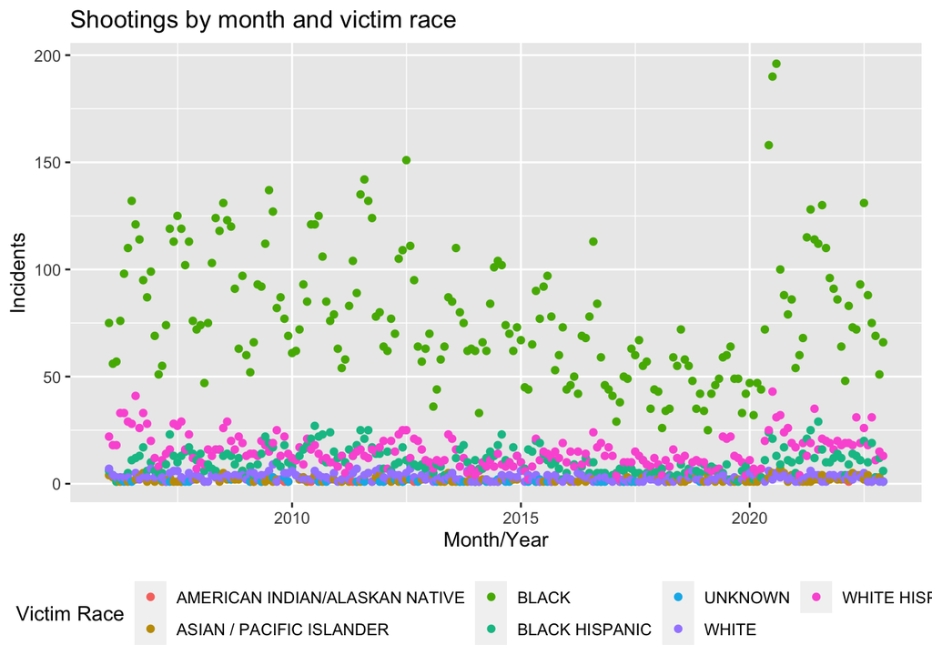

```r
NYPD_vic_race <- NYPD_clean %>%
          mutate(OCCUR_MONTH = format(as.Date(OCCUR_DATE), "%Y-%m")) %>%
          mutate(OCCUR_MONTH = ym(OCCUR_MONTH)) %>%
          group_by(OCCUR_MONTH, VIC_RACE) %>%
          summarise(Incident = n_distinct(INCIDENT_KEY)) %>%
          select(Incident, OCCUR_MONTH, VIC_RACE)
ggplot(NYPD_vic_race,aes(x=OCCUR_MONTH,y=Incident, col=VIC_RACE))+geom_point() + labs(title="Shootings by month and victim race",
                                                                                                  x ="Month/Year", y = "Incidents", col="Victim Race") + theme(legend.position="bottom")
```